# COVID19 Data

## COVID-19 Data Import

This document’s created to analyze COVID-19 Data published by Johns Hopkins University available through https://github.com/CSSEGISandData/COVID-19.

This Markdown uses **tidyverse** and **lubridate** R Packages.

```r
url_in <- "https://raw.githubusercontent.com/CSSEGISandData/COVID-19/master/csse_covid_19_data/csse_covid_19_time_series/"
file_names <- c("time_series_covid19_confirmed_US.csv",  "time_series_covid19_confirmed_global.csv", "time_series_covid19_deaths_US.csv",  "time_series_covid19_deaths_global.csv")
urls <- str_c(url_in,file_names)
US_cases <- read_csv(urls[1])
global_cases <- read_csv(urls[2])
US_deaths <- read_csv(urls[3])
global_deaths <- read_csv(urls[4])
uid <- read_csv("https://raw.githubusercontent.com/CSSEGISandData/COVID-19/master/csse_covid_19_data/UID_ISO_FIPS_LookUp_Table.csv") %>% select(-c(Lat, Long_, Combined_Key, code3, iso2, iso3, Admin2)) #for global population data
```

## Data Cleaning and Wrangling

Now let’s tidy up our data, putting it in the long format and joining both deaths and cases counts for global and US data sets:

```r
global_cases <- global_cases %>% pivot_longer(cols = -c(`Province/State`,`Country/Region`,Lat,Long), names_to = "date", values_to = "cases") %>% select(-c(Lat,Long))

global_deaths <- global_deaths %>% pivot_longer(cols = -c(`Province/State`,`Country/Region`,Lat,Long), names_to = "date", values_to = "deaths") %>% select(-c(Lat,Long))

global <- global_cases %>% full_join(global_deaths) %>% rename(Country_Region = `Country/Region`, Province_State = `Province/State`) %>% mutate(date = mdy(date))

global <- global %>% filter(cases>0) #Focusing from the point of counting cases

global <- global %>% unite("Combined_Key", c(Province_State, Country_Region), sep = ", ", na.rm = TRUE, remove = FALSE) #Adding Combined Key in the similar format as US data

global <- global %>% left_join(uid, by = c("Province_State", "Country_Region")) %>%
select(-c(UID, FIPS)) %>%
select(Province_State, Country_Region, date, cases, deaths, Population, Combined_Key) #Adding Population data

US_cases <- US_cases %>% pivot_longer(cols = -(UID:Combined_Key), names_to = "date", values_to = "cases") %>% select(Admin2:cases) %>% mutate(date = mdy(date)) %>% select(-c(Lat,Long_))

US_deaths <- US_deaths %>% pivot_longer(cols = -(UID:Population), names_to = "date", values_to = "deaths") %>% select(Admin2:deaths) %>% mutate(date = mdy(date)) %>% select(-c(Lat,Long_))

US <- US_cases %>% full_join(US_deaths)
```

Now let’s take a look at a summary of global and US tibbles:

```r
summary(global)
```

```
##  Province_State     Country_Region          date                cases
##  Length:306827      Length:306827      Min.   :2020-01-22   Min.   :        1
##  Class :character   Class :character   1st Qu.:2020-12-12   1st Qu.:     1316
##  Mode  :character   Mode  :character   Median :2021-09-16   Median :    20365
##                                        Mean   :2021-09-11   Mean   :  1032863
##                                        3rd Qu.:2022-06-15   3rd Qu.:   271281
##                                        Max.   :2023-03-09   Max.   :103802702
##
##      deaths          Population        Combined_Key
##  Min.   :      0   Min.   :6.700e+01   Length:306827
##  1st Qu.:      7   1st Qu.:7.866e+05   Class :character
##  Median :    214   Median :6.948e+06   Mode  :character
##  Mean   :  14405   Mean   :2.890e+07
##  3rd Qu.:   3665   3rd Qu.:2.914e+07
##  Max.   :1123836   Max.   :1.380e+09
##                    NA's   :6729
```

```r
summary(US)
```

```
##     Admin2          Province_State     Country_Region     Combined_Key
##  Length:3819906     Length:3819906     Length:3819906     Length:3819906
##  Class :character   Class :character   Class :character   Class :character
##  Mode  :character   Mode  :character   Mode  :character   Mode  :character
##
##
##
##       date                cases           Population           deaths
##  Min.   :2020-01-22   Min.   :  -3073   Min.   :       0   Min.   :  -82.0
##  1st Qu.:2020-11-02   1st Qu.:    330   1st Qu.:    9917   1st Qu.:    4.0
##  Median :2021-08-15   Median :   2272   Median :   24892   Median :   37.0
##  Mean   :2021-08-15   Mean   :  14088   Mean   :   99604   Mean   :  186.9
##  3rd Qu.:2022-05-28   3rd Qu.:   8159   3rd Qu.:   64979   3rd Qu.:  122.0
##  Max.   :2023-03-09   Max.   :3710586   Max.   :10039107   Max.   :35545.0
```

## Visaulizations & Analysis

Grouping US data by State, calculating to total cases and deaths/deaths per mill as well as population:

```r
US_by_state <- US %>% group_by(Province_State, Country_Region, date) %>% summarize(cases = sum(cases), deaths = sum(deaths), Population = sum(Population)) %>% mutate(deaths_per_mill = deaths *1000000 / Population) %>% select(Province_State, Country_Region, date, cases, deaths, deaths_per_mill, Population) %>% ungroup()

US_totals <- US_by_state %>% group_by(Country_Region, date) %>% summarize(cases = sum(cases), deaths = sum(deaths), Population = sum(Population)) %>% mutate(deaths_per_mill = deaths*100000 / Population) %>% ungroup()
```

Adding to columns for new cases and new deaths:

```r
US_by_state <- US_by_state %>% mutate(new_cases = cases - lag(cases), new_deaths = deaths - lag(deaths))

US_totals <- US_totals %>% mutate(new_cases = cases - lag(cases), new_deaths = deaths - lag(deaths))
```

Let’s see what states had the worst cases per thousand and deaths per thousand rates:

```r
US_state_totals <- US_by_state %>% group_by(Province_State) %>% summarize(deaths = max(deaths), cases = max(cases), population= max(Population), cases_per_thou = 1000* cases / population, deaths_per_thou = 1000 * deaths / population) %>% filter(cases > 0, population > 0)
US_state_totals %>% slice_max(deaths_per_thou, n = 10) %>% select(deaths_per_thou, cases_per_thou, everything())
```

```
## # A tibble: 10 × 6
##    deaths_per_thou cases_per_thou Province_State deaths   cases population
##              <dbl>          <dbl> <chr>           <dbl>   <dbl>      <dbl>
##  1            4.55           336. Arizona         33102 2443514    7278717
##  2            4.54           326. Oklahoma        17972 1290929    3956971
##  3            4.49           333. Mississippi     13370  990756    2976149
##  4            4.44           359. West Virginia    7960  642760    1792147
##  5            4.32           320. New Mexico       9061  670929    2096829
##  6            4.31           334. Arkansas        13020 1006883    3017804
##  7            4.29           335. Alabama         21032 1644533    4903185
##  8            4.28           368. Tennessee       29263 2515130    6829174
##  9            4.23           307. Michigan        42205 3064125    9986857
## 10            4.06           385. Kentucky        18130 1718471    4467673
```

as you can see *Arizona* and *Oklahoma* have the highest rates of deaths per thousand.

Now lets visualized what was the trend for cases and deaths for these two states:

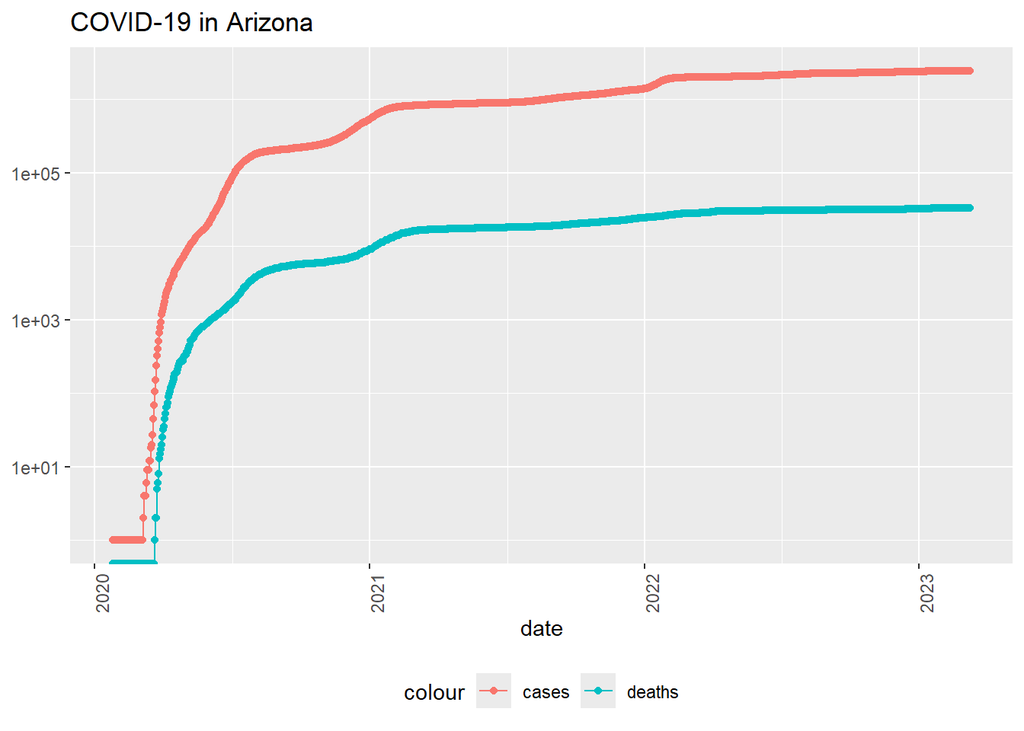

```r
state <- US_state_totals %>% slice_max(deaths_per_thou, n = 1) %>% pull(Province_State)

US_by_state %>%
  filter(Province_State == state) %>%
  filter(cases > 0) %>%
  ggplot(aes(x = date, y = cases)) +
  geom_line(aes(color = "cases")) +
  geom_point(aes(color = "cases")) +
  geom_line(aes(y = deaths, color = "deaths")) +
  geom_point(aes(y = deaths, color = "deaths")) +
  scale_y_log10() +
  theme(legend.position = "bottom", axis.text.x = element_text(angle = 90)) +
  labs(title = str_c("COVID-19 in ", state), y = NULL)
```

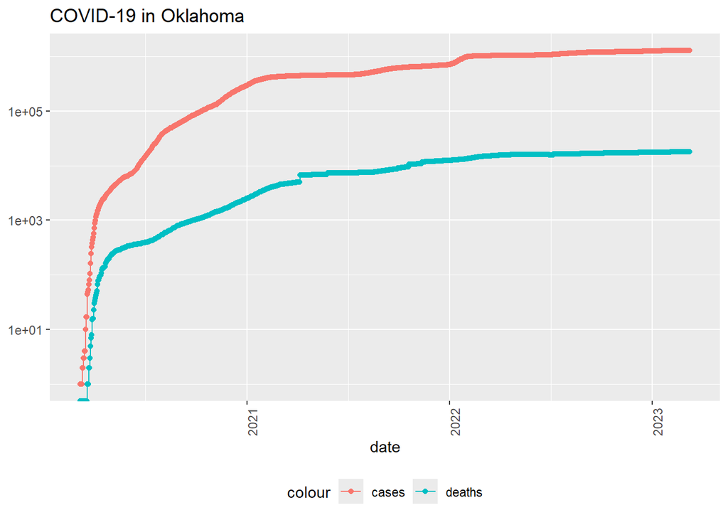

```r
state <- US_state_totals %>% slice_max(deaths_per_thou, n = 2) %>% slice(2) %>% pull(Province_State)

US_by_state %>%
  filter(Province_State == state) %>%
  filter(cases > 0) %>%
  ggplot(aes(x = date, y = cases)) +
  geom_line(aes(color = "cases")) +
  geom_point(aes(color = "cases")) +
  geom_line(aes(y = deaths, color = "deaths")) +
  geom_point(aes(y = deaths, color = "deaths")) +
  scale_y_log10() +
  theme(legend.position = "bottom", axis.text.x = element_text(angle = 90)) +
  labs(title = str_c("COVID-19 in ", state), y = NULL)
```

Now these two graphs do not tell us what was the trend for new_cases and new_deaths as we progressed through the pandemic, for that we can use new_cases and new_deaths columns:

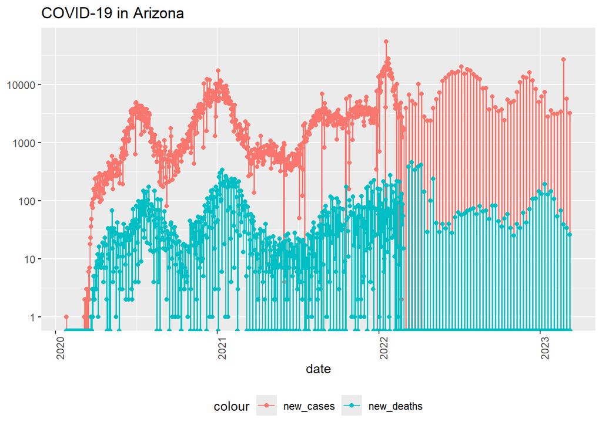

```r
state <- US_state_totals %>% slice_max(deaths_per_thou, n = 1) %>% pull(Province_State)

US_by_state %>%
  filter(Province_State == state) %>%
  filter(cases > 0) %>%
  ggplot(aes(x = date, y = new_cases)) +
  geom_line(aes(color = "new_cases")) +
  geom_point(aes(color = "new_cases")) +
  geom_line(aes(y = new_deaths, color = "new_deaths")) +
  geom_point(aes(y = new_deaths, color = "new_deaths")) +
  scale_y_log10() +
  theme(legend.position = "bottom", axis.text.x = element_text(angle = 90)) +
  labs(title = str_c("COVID-19 in ", state), y = NULL)
```

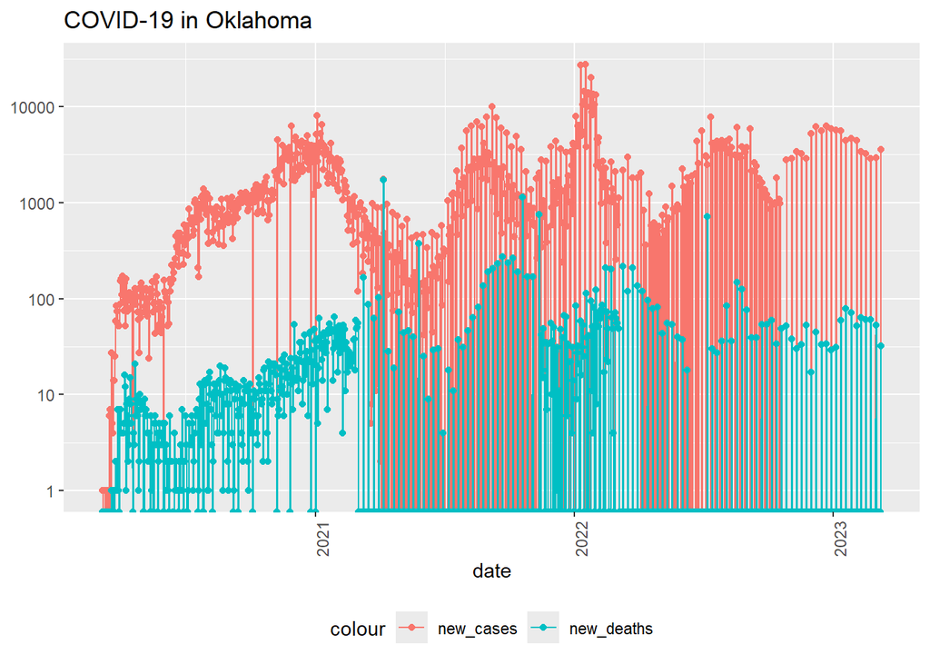

```r
state <- US_state_totals %>% slice_max(deaths_per_thou, n = 2) %>% slice(2) %>% pull(Province_State)

US_by_state %>%
  filter(Province_State == state) %>%
  filter(cases > 0) %>%
  ggplot(aes(x = date, y = new_cases)) +
  geom_line(aes(color = "new_cases")) +
  geom_point(aes(color = "new_cases")) +
  geom_line(aes(y = new_deaths, color = "new_deaths")) +
  geom_point(aes(y = new_deaths, color = "new_deaths")) +
  scale_y_log10() +
  theme(legend.position = "bottom", axis.text.x = element_text(angle = 90)) +
  labs(title = str_c("COVID-19 in ", state), y = NULL)
```

## Model

We can develop a model for the US new_deaths as a variable of new_cases for different states, to predict the relation between the two for each state:

```r
mod <- lm(new_deaths ~ new_cases + Province_State, data = US_by_state)
```

```r
summary(mod)
```

```
##
## Call:
## lm(formula = new_deaths ~ new_cases + Province_State, data = US_by_state)
##
## Residuals:
##      Min       1Q   Median       3Q      Max
## -13791.4     -4.9      0.0      5.5  24627.9
##
## Coefficients:
##                                          Estimate Std. Error  t value Pr(>|t|)
## (Intercept)                             3.481e+00  4.925e+00    0.707   0.4797
## new_cases                               1.037e-02  7.637e-06 1358.006  < 2e-16
## Province_StateAlaska                   -8.451e+00  6.963e+00   -1.214   0.2249
## Province_StateAmerican Samoa           -2.035e+00  6.963e+00   -0.292   0.7701
## Province_StateArizona                   3.353e+00  6.963e+00    0.481   0.6302
## Province_StateArkansas                 -8.015e+00  6.963e+00   -1.151   0.2497
## Province_StateCalifornia               -2.730e+01  6.964e+00   -3.920 8.86e-05
## Province_StateColorado                  1.448e+01  6.964e+00    2.079   0.0376
## Province_StateConnecticut               1.951e+00  6.963e+00    0.280   0.7793
## Province_StateDelaware                 -5.404e+00  6.963e+00   -0.776   0.4377
## Province_StateDiamond Princess         -3.388e+00  6.963e+00   -0.487   0.6266
## Province_StateDistrict of Columbia     -3.843e+00  6.963e+00   -0.552   0.5811
## Province_StateFlorida                   4.133e+00  6.963e+00    0.593   0.5529
## Province_StateGeorgia                  -1.401e+00  6.963e+00   -0.201   0.8405
## Province_StateGrand Princess           -1.281e+01  6.963e+00   -1.840   0.0658
## Province_StateGuam                     -3.669e+00  6.963e+00   -0.527   0.5982
## Province_StateHawaii                   -5.138e+00  6.963e+00   -0.738   0.4606
## Province_StateIdaho                    -1.628e+00  6.963e+00   -0.234   0.8151
## Province_StateIllinois                 -4.238e+00  6.963e+00   -0.609   0.5427
## Province_StateIndiana                   1.502e+00  6.963e+00    0.216   0.8292
## Province_StateIowa                     -6.537e+00  6.963e+00   -0.939   0.3479
## Province_StateKansas                   -4.368e+00  6.963e+00   -0.627   0.5305
## Province_StateKentucky                 -3.506e+00  6.963e+00   -0.504   0.6146
## Province_StateLouisiana                -1.612e+00  6.963e+00   -0.232   0.8169
## Province_StateMaine                    -5.944e+00  6.963e+00   -0.854   0.3934
## Province_StateMaryland                 -1.071e+00  6.963e+00   -0.154   0.8778
## Province_StateMassachusetts            -4.462e+00  6.963e+00   -0.641   0.5217
## Province_StateMichigan                  4.535e+00  6.963e+00    0.651   0.5149
## Province_StateMinnesota                -1.573e+01  6.963e+00   -2.260   0.0239
## Province_StateMississippi               2.358e+00  6.963e+00    0.339   0.7349
```

[output cut: 81 more lines]

```
## Province_StateUtah                     .
## Province_StateVermont
## Province_StateVirgin Islands
## Province_StateVirginia
## Province_StateWashington
## Province_StateWest Virginia
## Province_StateWisconsin
## Province_StateWyoming
## ---
## Signif. codes:  0 '***' 0.001 '**' 0.01 '*' 0.05 '.' 0.1 ' ' 1
##
## Residual standard error: 166.4 on 66234 degrees of freedom
##   (1 observation deleted due to missingness)
## Multiple R-squared:  0.9654, Adjusted R-squared:  0.9653
## F-statistic: 3.183e+04 on 58 and 66234 DF,  p-value: < 2.2e-16
```

Now let’s see how the prediction compares with actual data:

```r
US_by_state_estimate <- US_by_state %>% filter(!is.na(new_deaths)) %>% filter(!is.na(new_cases)) %>% mutate(pred = predict(mod))
```

Plotting the result for *Arizona* on a Log-Log scale graph:

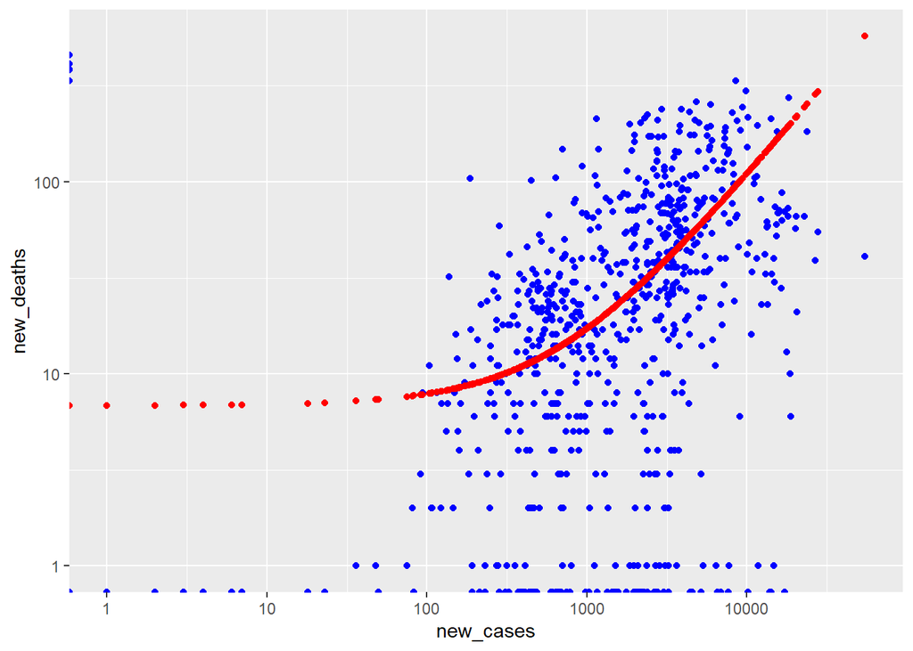

```r
US_by_state_estimate %>% filter(Province_State == US_state_totals %>% slice_max(deaths_per_thou, n = 1) %>% pull(Province_State)) %>% ggplot()+ geom_point(aes(x= new_cases, y = new_deaths), color = "blue") + geom_point(aes(x = new_cases, y = pred), color = "red") + scale_x_log10() + scale_y_log10()
```

As you can see there are a lot of outliers in the data for *Arizona*, but in general the model tries to find the best line that would fit the relation between new cases and new deaths.

## Sources of Bias & Conclusion

There are some sources of bias here, the first one is the quality of tests being done and the vastness of testing for new cases. Some states might test extensively some may not and that could impact the results. Also, another factor and source of bias comes from demographics of each state, the age groups the racial information and also the level healthcare provided for new cases. These could all impact the relationship between new cases and deaths.

Overall what we have done here was to see the trend over time of cases and deaths, find the states with most deaths per thousand rates, see the trends for their cases and deaths overtime, and at the end we developed a linear model for new_deaths based on new_cases and the state. We then compared the model for *Arizona* and compared the predictions with the actual data. The sources of bias here would impact the prediction and we need more demographic information to improve the model and make it more accurate.